# Florida Populations by County

#### For work I have been looking at some counties in Florida. I thought it would be cool to look at some population data and then map them by county.

```r
library(tidyverse)
library(rvest)
```

##### I am going to scrap some data from a website that has the population for each county in Florida.

```r
url <- "https://www.florida-demographics.com/counties_by_population"
h <- read_html(url)
tab <- h %>% html_nodes("table")
tab <- tab %>% html_table
FloridaDemographics <- as.data.frame(tab)
```

##### Converting character columns to numeric

```r
FloridaDemographics$Rank <- as.numeric(FloridaDemographics$Rank)
FloridaDemographics$Population <- parse_number(FloridaDemographics$Population)
```

##### Removing the last row because it is needless text

```r
FloridaDemographics <- FloridaDemographics[-c(68),]
```

##### Loading the packages I need and getting the Florida Longitude and Latitude data

```r
library(maps)
library(ggmap)
library(mapdata)
```

##### The map_data in ggplot2 has longitude and latitude data.

```r
states <- map_data("state")
FL_df <- subset(states, region == "florida")
counties <- map_data("county")
FL_counties <- subset(counties, region == "florida")
```

##### Eventually I’ll have to merge FloridaDemographics and Fl_counties, but I need something to match them by. Let me see what they share.

```r
head(FloridaDemographics)
```

```
##   Rank              County Population
## 1    1   Miami-Dade County    2715516
## 2    2      Broward County    1909151
## 3    3   Palm Beach County    1446277
## 4    4 Hillsborough County    1378883
## 5    5       Orange County    1321194
## 6    6     Pinellas County     957875
```

```r
unique(FL_counties$subregion)
```

```
##  [1] "alachua"      "baker"        "bay"          "bradford"     "brevard"
##  [6] "broward"      "calhoun"      "charlotte"    "citrus"       "clay"
## [11] "collier"      "columbia"     "miami-dade"   "de soto"      "dixie"
## [16] "duval"        "escambia"     "flagler"      "franklin"     "gadsden"
## [21] "gilchrist"    "glades"       "gulf"         "hamilton"     "hardee"
## [26] "hendry"       "hernando"     "highlands"    "hillsborough" "holmes"
## [31] "indian river" "jackson"      "jefferson"    "lafayette"    "lake"
## [36] "lee"          "leon"         "levy"         "liberty"      "madison"
## [41] "manatee"      "marion"       "martin"       "monroe"       "nassau"
## [46] "okaloosa"     "okeechobee"   "orange"       "osceola"      "palm beach"
## [51] "pasco"        "pinellas"     "polk"         "putnam"       "st johns"
## [56] "st lucie"     "santa rosa"   "sarasota"     "seminole"     "sumter"
## [61] "suwannee"     "taylor"       "union"        "volusia"      "wakulla"
## [66] "walton"       "washington"
```

#### The “subregion” column corresponds with the county name, but it is not capitalized and does not have “County” at the end like the FloridaDemographics. So, within the Fl_counties dataframe, I’m going to create a replicate column of subregion that I will use to match the format of the other dataframe. I’ll call it “County.” Then I’ll paste “County” to the end of each value in the new column.

```r
FL_counties$county <- FL_counties$subregion
FL_counties$county <- paste(FL_counties$county, "County" )
```

##### But the first letter is still not capitalized. I’ll create a functions called “simplecap” that capitalizes the first letter, and then apply the function over each value. Third, I’ll change the column name using the colnames function.

```r
simpleCap <- function(x) {
  s <- strsplit(x, " ")[[1]]
  paste(toupper(substring(s, 1,1)), substring(s, 2),
        sep="", collapse=" ")
}

FL_counties$county <- sapply(FL_counties$county, simpleCap)
colnames(FL_counties)[7] <- "County"
```

##### Merging the Long and Lat data with the demographics by the “County” column in each dataframe.

```r
Florida_merged <- inner_join(FloridaDemographics, FL_counties, by = "County")
```

##### Looking at the data, it appears Miami-Dade County did not merge. The Fl_counties data was “Miami-dade County” while the FloridaDemographics was “Miami-Dade County.” Let me see if there are any other Counties that did not merged. I can check this by looking at the “Rank” variable in the new merged data.

```r
unique(Florida_merged$Rank)
```

```
##  [1]  2  3  4  5  6  7  8  9 10 11 12 13 14 15 16 17 18 19 20 22 23 25 26 27 28
## [26] 29 30 31 32 33 34 35 36 37 38 39 40 41 42 43 44 45 46 47 49 50 51 52 53 54
## [51] 55 56 57 58 59 60 61 62 63 64 65 66 67
```

##### Counties with Ranks 21, 24, and 48 were also not merged. What are the names for each county?

```r
FloridaDemographics
```

```
##    Rank              County Population
## 1     1   Miami-Dade County    2715516
## 2     2      Broward County    1909151
## 3     3   Palm Beach County    1446277
## 4     4 Hillsborough County    1378883
## 5     5       Orange County    1321194
## 6     6     Pinellas County     957875
## 7     7        Duval County     924229
## 8     8          Lee County     718679
## 9     9         Polk County     668671
## 10   10      Brevard County     576808
## 11   11      Volusia County     527634
## 12   12        Pasco County     510593
## 13   13     Seminole County     455086
## 14   14     Sarasota County     412144
```

[output cut: 53 more lines]

##### The counties are St. Lucie, St. Johns, and DeSoto. I will change the spelling of the counties in the the Fl_counties dataframe so they match the spelling of the counties I scraped from the web

```r
FL_counties$County[FL_counties$County == "Miami-dade County"] <- "Miami-Dade County"
FL_counties$County[FL_counties$County == "St Lucie County"] <- "St. Lucie County"
FL_counties$County[FL_counties$County == "St Johns County"] <- "St. Johns County"
FL_counties$County[FL_counties$County == "De Soto County"] <- "DeSoto County"
```

##### Now that Fl_counties has the same names, I can redo the inner join. Then I’ll check to make sure there are 67 unique ranks (1 for each county).

```r
Florida_merged <- inner_join(FloridaDemographics, FL_counties, by = "County")
length(unique(Florida_merged$Rank))
```

```
## [1] 67
```

##### Time to plot. First let me create the base map.

```r
Fl_base <- ggplot(data = Florida_merged, mapping = aes(x = long, y = lat, group = group))+
  coord_fixed(1.3)+
  geom_polygon(color = "black", fill = "gray")
```

##### Now I will use geom_polygon and fill the map with populations for each county.

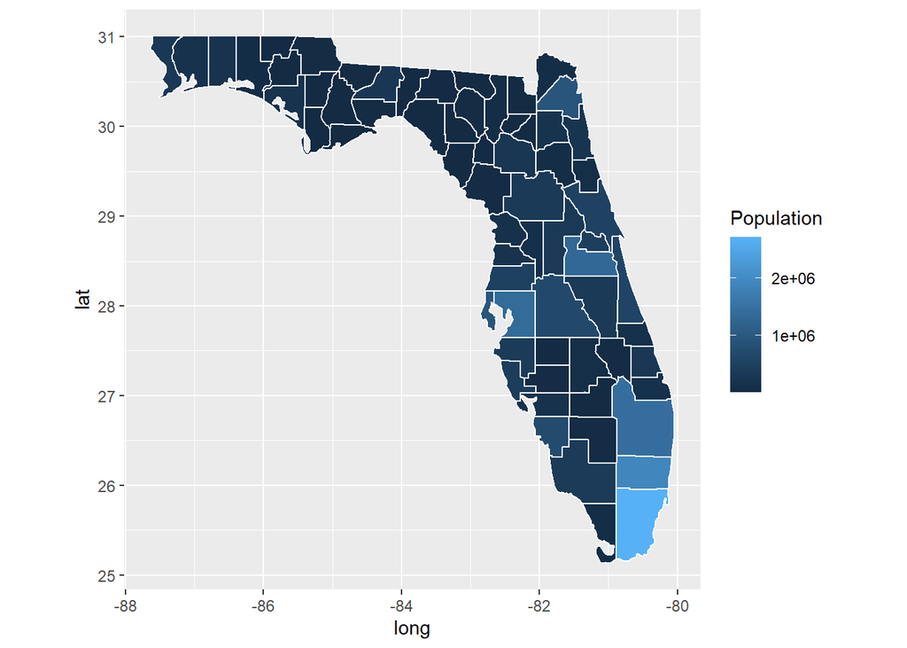

```r
Fl_base +
  geom_polygon(aes(fill = Population), color = "white")
```

##### This map legend uses scientific notation, and I want to create more breaks in the legend. So I’ll load the scales package and use the labels function. I’ll also create some breaks for the population range.

```r
library(scales)
```

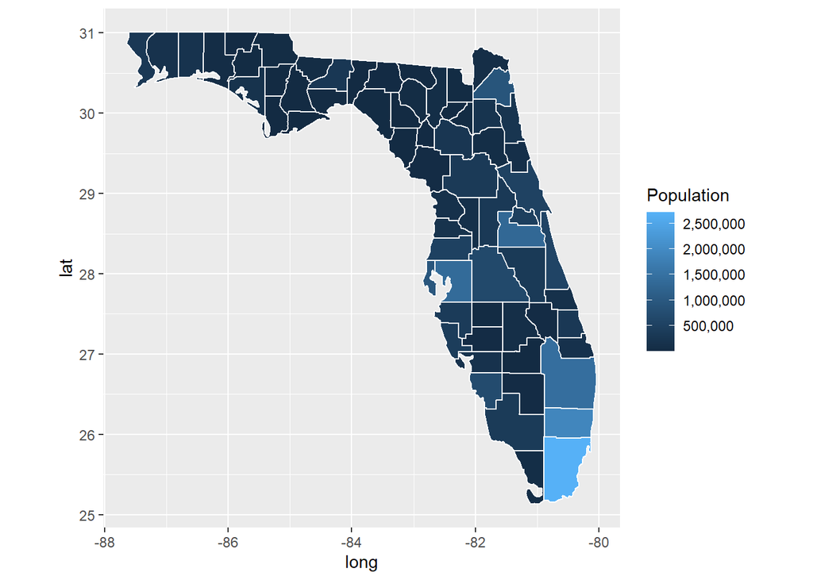

```r
Fl_base +
  geom_polygon(aes(fill = Population), color = "white")+
  scale_fill_gradient(labels = comma, breaks = c(0, 500000, 1000000, 1500000, 2000000, 2500000, 3000000))
```